# Linear Models: Homework 1

Roel Jude Bagaforo

30 October 2022

# 1 Homework Summary

For this homework, we consider a pre-clinical study of ADDF19 which was subjected for evaluation of potential negative side effects on blood serum levels of Immunoglobulin G1. Eighteen mice were grouped by 3 and were administered with 6 different doses of ADDF19.

The following outputs were arranged according to the order of the research questions. An executive summary and a simulation study were presented at the end. All statistical analysis were performed in RStudio 2022.07.0+548.

# 2 Data Descriptives

```r
skim_without_charts(mice)
```

Data summary

| Name | mice |
| --- | --- |
| Number of rows | 18 |
| Number of columns | 2 |
| _______________________ |  |
| Column type frequency: |  |
| numeric | 2 |
| ________________________ |  |
| Group variables | None |

**Variable type: numeric**

| skim_variable | n_missing | complete_rate | mean | sd | p0 | p25 | p50 | p75 | p100 |
| --- | --- | --- | --- | --- | --- | --- | --- | --- | --- |
| concentration | 0 | 1 | 1.17 | 0.51 | 0.50 | 0.75 | 1.12 | 1.50 | 2.00 |
| IgG1 | 0 | 1 | 2.52 | 0.30 | 1.79 | 2.44 | 2.55 | 2.63 | 3.16 |

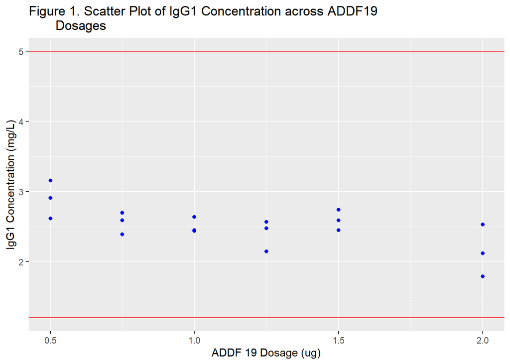

```r
par(mfrow=c(1,1))
ggplot(mice, aes(concentration,IgG1)) + geom_point(color="blue") +
  labs(title="Figure 1. Scatter Plot of IgG1 Concentration across ADDF19
       Dosages") +
  xlab("ADDF 19 Dosage (ug)") + ylab ("IgG1 Concentration (mg/L)") +
  geom_hline(yintercept=1.2, color="red") +
  geom_hline(yintercept=5, color="red")
```

```r
#geom_hline are cut off for normal concentration values of IgG1
```

The data was consist of two variables, namely the different ADDF19 dosages and corresponding concentration levels of IgG1. Graphically, it was observed that there was a slightly noticeable decreasing IgG1 concentration associated with increasing ADDF19 dosage. Also, all of the recorded IgG1 concentrations were inside the normal IgG1 values (as shown in Figure 1, all points were inside the two red lines).

# 3 Question 1

## 3.1 Question 1.1

What is the effect of the concentration of ADDF19 on the mean IgG1 blood level concentrations?

In order to answer this research question, a simple linear regression was employed. The model that was considered was specified as follows:

$$Y_i = β_0 + β_1X_i + \varepsilon_i$$
where $Y_i$ refers to the IgG1 blood concentration levels for mouse i=1 to 18, $X_i$ refers to the ADDF19 dosage for mouse i=1 to 18, and β are the regression coefficients and $\varepsilon_i$ as the error term.

```r
model <- lm(IgG1~concentration, data=mice)
model_summary <- summary(model)
pander(model_summary)
```

|  | Estimate | Std. Error | t value | Pr(>\|t\|) |
| --- | --- | --- | --- | --- |
| **(Intercept)** | 2.968 | 0.143 | 20.76 | 5.392e-13 |
| **concentration** | -0.3869 | 0.1129 | -3.427 | 0.003457 |

Fitting linear model: IgG1 ~ concentration

| Observations | Residual Std. Error | $R^2$ | Adjusted $R^2$ |
| --- | --- | --- | --- |
| 18 | 0.2361 | 0.4233 | 0.3873 |

By fitting a simple linear regression, it was found out that the estimated effect, on average, of one (1) $\mu$g increase of ADDF19 dosage decreased the IgG1 blood concentration levels by 0.3869 mg/L. In other words, it was observed that there was an inverse relationship between the ADDF19 dosage and IgG1 blood concentration levels.

## 3.2 Question 1.2

Give an appreciation of the (im)precision of the previous estimate (standard error and a 95% confidence interval).

```r
model_summary$coefficients[2,2] #standard error of B1
```

```
## [1] 0.1128954
```

```r
ci_model <- confint(model) #CI of B1
pander(ci_model)
```

|  | 2.5 % | 97.5 % |
| --- | --- | --- |
| **(Intercept)** | 2.665 | 3.271 |
| **concentration** | -0.6262 | -0.1476 |

Looking into the standard error of the estimate, it was 0.1129, which was quite small. In addition, the 95% confidence interval of the estimated average effect ($\beta_1$) was (-0.6262, -0.1476). Which means, 95% of the time, the effect of an increase in ADDF19 dosage on the decrease on IgG1 blood concentration level was within 0.14 to 0.62. The confidence interval did not contain zero (0) suggesting that the estimated effect was significant (but this was explained better in the hypothesis test in the next section).

## 3.3 Question 1.3

Is there a significant effect of the concentration of ADDF19 on the mean IgG1 blood level of concentrations? This test must be performed at the 5% level of significance.

The study was formulated to test if there was a negative effect brought by ADDF19 on IgG1 concentration. Hence, a one-sided test for $\beta_1$ was the most appropriate. The following were the null and the alternative hypothesis:
$$H_0:{\beta}_1 = 0$$
$$H_1: {\beta}_1 < 0$$
Based on the previous output of the simple linear regression model, the t-value was -3.427 with a corresponding p-value of 0.0035. However, the t-test that was done for the previous output was a two-sided test. Therefore, in order to compute for p-value of the one-sided test, needed for this question, the two-sided p-value was divided by two (2).

```r
model_summary$coefficients[2,4]/2 #p-value of B1
```

```
## [1] 0.001728316
```

The p-value of the one-sided test was 0.0017, which was lower than the $\alpha=0.05$. Thus, the estimated -0.3869 mg/L average effect on IgG1 blood concentration levels by one (1) $\mu$g increase in ADDF19 dosage was significant.

## 3.4 Executive Summary

A pre-clinical study was done to evaluate the negative effect of the new drug, ADDF19, on the IgG1 blood concentration levels. Six different ADDF19 dosage were given to 18 mice and their IgG1 concentration levels were recorded. To answer the research questions, a simple linear regression model was used. Simple linear regression model is a model that describes a relationship of the dependent variable and the independent variable. For this study, the dependent variable was the IgG1 concentration and the independent variable was the ADDF19 dosages. We expect that with this model we can have an estimate of the effect of unit increase in ADDF19 to the IgG1 concentration and the direction of the effect (whether positive or negative).

Results showed that one (1) $\mu$g increase in ADDF dosage will decrease the IgG1 blood concentration levels by 0.3869 mg/L. Furthermore, this estimated negative effect can be between 0.15 to 0.63, 95% of the time. The estimated effect was subjected to hypothesis testing, and it was found out that the effect was statistically significant. Therefore, an increase in ADDF19 dosages can be associated with a decrease in IgG1 levels. However, it should be noted that even the highest dosage that was used in this study, the IgG1 blood concentration level was still inside the healthy range. The ADDF19 dosage that will cause unhealthy IgG1 blood concentration levels was estimated to be around more than 2.88 $\mu$g dosage (based on the simple linear regression estimate).

```r
#concentration = 2 ug ADDF19
predict(model, newdata=data.frame(concentration=2), interval="prediction")
```

```
##       fit      lwr      upr
## 1 2.19419 1.642568 2.745813
```

```r
#concentration that will breach 1.2 healthy cutoff
predict(model, newdata=data.frame(concentration=2.88), interval="prediction")
```

```
##        fit      lwr      upr
## 1 1.853714 1.195953 2.511476
```

# 4 Question 2 (Simulation)

In this part, a simulation was done to determine the minimum sample required for obtaining a power of 0.80 given different values of $\beta_1$. Parameters, such as the $\sigma^2$ and the $\beta_0$ were considered fixed.

This simulation was arranged following the test for $\beta_1$. $H_0:{\beta}_1 = 0$ $H_1: {\beta}_1 < 0$ where the test statistic is
$$T =
\frac{\hat\beta_1}{\hat\sigma_{\beta_1}}$$
With this test statistic, the only needed values are: (1) the $\hat\beta_1$ which were range of values that was set; (2) and the $\hat\sigma_{\beta_1}$ which was computed through the fixed $\sigma^2$, as estimated by the MSE, and the the distributed regressors over the sample size. Thus, no computations based on $Y_i$ was done as the two needed values did not depend on $Y_i$. A function for $\hat\sigma_{\beta_1}$ was formulated were the six (6) predetermined and original regressors were repeated and assigned sequentially until all n rows have a regressor value. For this simulation, the sample size was not restricted to be a multiple of the 6 (number of regressors) to allow for more flexibility in the determination of minimum sample size required (but in case of “balanced” design, codes were also prepared, mentioned in the comments below). Consequentially, the power was computed with the given $\alpha$=0.05, $\hat\beta_1$ in the sequence, and the standard error computed in the previous function. A for-while loop was then used to determine the minimum sample to reach a power of 0.80. The plot of the simulation data and the codes are presented below:

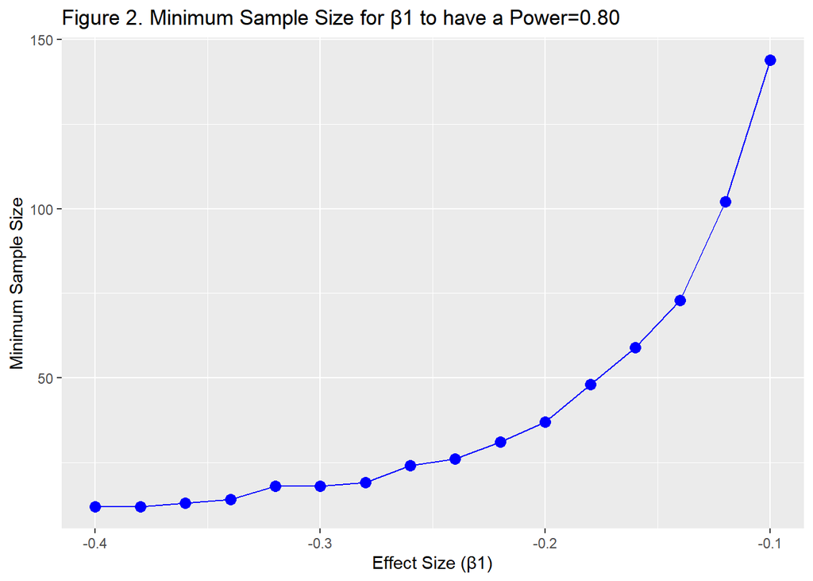

```r
beta1_se <- function(a){
#function for sigma2 of beta_1
#a is the n=sample
regressors <- c(0.5,0.75,1,1.25,1.5,2) #original 6 regressors
x <- matrix(nrow=a,ncol=2)
x[,1] <- 1
x[,2] <- rep(regressors,length.out=a)
#regressors are repeated sequentially until last row, thus it can be unbalanced
#meaning not all 6 regressors have the same number
#x[,2] <- rep(regressors, by=6) for balanced design
mse <- sum(model$residuals^2)/(18-2) #from the original model, df=18-2
se <- solve(t(x)%*%x)[2,2]*mse #sigma2 of beta_1
return(se)
}
beta1seq <- seq(-0.4,-0.1, by=0.02) #range of test beta_1 values
simulation <- matrix(nrow=16,ncol=2)
simulation[,1] <- c(beta1seq)
simulation[,2] <- 0
i <- 1
for(n in beta1seq){
#n is the value in beta1seq
  power <- 0 #initialize
  min_sample <- 3 #initialize, 3 so df in power not be 0
  #min_sample set to 6 for balanced design
  while(power<0.80){ #stops until min_sample satisfies power of 0.80
    min_sample <- min_sample+1 #6 for balanced design
    power <- pt(-qt(0.95,df=min_sample-2),df=min_sample-2,ncp=n/sqrt(beta1_se(min_sample)))
    #power computes for the power given the alpha=0.05 (0.95), and ncp=test
    #beta_1/se, one sided power test
    #power can be computed through pwr.t.test from package pwr, however
    #df is fixed as n-1
  }
  simulation[i,2] <-min_sample #records the sample for given test beta_1
  i <- i+1
}
sim_data <- as.data.frame(simulation)
ggplot(sim_data,aes(V1,V2)) +
  geom_point(color="blue", size=3) +
  geom_line(color="blue") +
  labs(title="Figure 2. Minimum Sample Size for β1 to have a Power=0.80") +
  xlab("Effect Size (β1)") + ylab ("Minimum Sample Size")
```

From the plot, it can be observed that the needed sample size for values of $\beta_1$ , the effect size, as it nears zero (0) rapidly increases.